# Indian Food Analysis

## Analysis

What is the most common diet in Indian food?

In our data set, the most common kind of food is vegetarian with 226 out of 255 dishes.

what is the most common ingredients?

```
## [1] "sugar"
```

what is the average perp time?

```
##   avg_prep_time
## 1      35.38667
```

what is the average cooking time?

```
##   avg_cook_time
## 1      38.91189
```

average cooking time total time (perp+cook)

```
##   avg_total_cooking_time
## 1               74.29856
```

range of prep time

|  | range_prep_time |
| --- | --- |
| 1 | 5 |
| 2 | 500 |

range of cooking time

|  | range_cook_time |
| --- | --- |
| 1 | 2 |
| 2 | 720 |

what is the most common course type?

```
## [1] "main course"
```

# what is the most common flavor profile?

```
## [1] "spicy"
```

#what is the most common ingredients in a course type?

|  | course | tail(names(sort(table(ingredients))), 1) |
| --- | --- | --- |
| 1 | dessert | sugar |
| 2 | main course | ginger |
| 3 | snack | urad dal |
| 4 | starter | yogurt |

#what is the most common ingredients in a flavor type?

|  | flavor_profile | tail(names(sort(table(ingredients))), 1) |
| --- | --- | --- |
| 1 | bitter | fenugreek leaves |
| 2 | sour | sugar |
| 3 | spicy | ginger |
| 4 | sweet | sugar |

#what is the most common course in a state/region?  
# state

|  | state | tail(names(sort(table(course))), 1) |
| --- | --- | --- |
| 1 | Andhra Pradesh | dessert |
| 2 | Assam | main course |
| 3 | Bihar | main course |
| 4 | Chhattisgarh | snack |
| 5 | Goa | dessert |
| 6 | Gujarat | snack |
| 7 | Haryana | main course |
| 8 | Jammu &amp; Kashmir | main course |
| 9 | Karnataka | main course |
| 10 | Kerala | main course |

[output cut: 14 more lines]

# region

|  | region | tail(names(sort(table(course))), 1) |
| --- | --- | --- |
| 1 | Central | snack |
| 2 | East | dessert |
| 3 | North | main course |
| 4 | North East | main course |
| 5 | South | main course |
| 6 | West | main course |

#what is the most common ingredients in a state/region?  
# state

|  | state | tail(names(sort(table(ingredients))), 1) |
| --- | --- | --- |
| 1 | Andhra Pradesh | Rice flour |
| 2 | Assam | mustard oil |
| 3 | Bihar | Yoghurt |
| 4 | Chhattisgarh | whole wheat flour |
| 5 | Goa | wine vinegar |
| 6 | Gujarat | sugar |
| 7 | Haryana | gram flour |
| 8 | Jammu &amp; Kashmir | tomatoes |
| 9 | Karnataka | jaggery |
| 10 | Kerala | yellow mustard |

[output cut: 14 more lines]

# region

|  | region | tail(names(sort(table(ingredients))), 1) |
| --- | --- | --- |
| 1 |  | Whole wheat flour |
| 2 | Central | whole wheat flour |
| 3 | East | sugar |
| 4 | North | garam masala |
| 5 | North East | mustard oil |
| 6 | South | curry leaves |
| 7 | West | sugar |

#what is the most common flavor type in a state/region?  
# state

|  | state | tail(names(sort(table(flavor_profile))), 1) |
| --- | --- | --- |
| 1 | Andhra Pradesh | sweet |
| 2 | Assam | spicy |
| 3 | Bihar | spicy |
| 4 | Chhattisgarh | spicy |
| 5 | Goa | sweet |
| 6 | Gujarat | spicy |
| 7 | Haryana | spicy |
| 8 | Jammu &amp; Kashmir | sweet |
| 9 | Karnataka | sweet |
| 10 | Kerala | spicy |

[output cut: 14 more lines]

# region

|  | region | tail(names(sort(table(flavor_profile))), 1) |
| --- | --- | --- |
| 1 | Central | spicy |
| 2 | East | sweet |
| 3 | North | spicy |
| 4 | North East | spicy |
| 5 | South | spicy |
| 6 | West | spicy |

#what is the most common diet in a state/region?  
# state

|  | state | s1 |
| --- | --- | --- |
| 1 | Andhra Pradesh | vegetarian |
| 2 | Assam | vegetarian |
| 3 | Bihar | vegetarian |
| 4 | Chhattisgarh | vegetarian |
| 5 | Goa | vegetarian |
| 6 | Gujarat | vegetarian |
| 7 | Haryana | vegetarian |
| 8 | Jammu &amp; Kashmir | vegetarian |
| 9 | Karnataka | vegetarian |
| 10 | Kerala | vegetarian |

[output cut: 14 more lines]

# reigon

|  | region | tail(names(sort(table(diet))), 1) |
| --- | --- | --- |
| 1 | Central | vegetarian |
| 2 | East | vegetarian |
| 3 | North | vegetarian |
| 4 | North East | non vegetarian |
| 5 | South | vegetarian |
| 6 | West | vegetarian |

#what is the average prep time / cooking time in a state/region?  
# prep time / state

|  | state | avg |
| --- | --- | --- |
| 1 | Andhra Pradesh | 61 |
| 2 | Assam | 11.8181818181818 |
| 3 | Bihar | 21.6666666666667 |
| 4 | Chhattisgarh | 10 |
| 5 | Goa | 15 |
| 6 | Gujarat | 15.6451612903226 |
| 7 | Haryana | 10 |
| 8 | Jammu &amp; Kashmir | 20 |
| 9 | Karnataka | 60.8333333333333 |
| 10 | Kerala | 82.1428571428571 |

[output cut: 13 more lines]

# prep time / region

|  | region | avg |
| --- | --- | --- |
| 1 | Central | 13.3333333333333 |
| 2 | East | 43.5185185185185 |
| 3 | North | 38.0208333333333 |
| 4 | North East | 28.8461538461538 |
| 5 | South | 58.1818181818182 |
| 6 | West | 16.9242424242424 |

# cooking time / state

|  | state | avg |
| --- | --- | --- |
| 1 | Andhra Pradesh | 37.5 |
| 2 | Assam | 28.1818181818182 |
| 3 | Bihar | 66.6666666666667 |
| 4 | Chhattisgarh | 60 |
| 5 | Goa | 50 |
| 6 | Gujarat | 30.0322580645161 |
| 7 | Haryana | 60 |
| 8 | Jammu &amp; Kashmir | 50 |
| 9 | Karnataka | 44.1666666666667 |
| 10 | Kerala | 33.5714285714286 |

[output cut: 13 more lines]

# cooking time / region

|  | region | avg |
| --- | --- | --- |
| 1 | Central | 48.3333333333333 |
| 2 | East | 41.6071428571429 |
| 3 | North | 41.9791666666667 |
| 4 | North East | 28.4615384615385 |
| 5 | South | 36.9090909090909 |
| 6 | West | 41.8805970149254 |

# the region which has the highest number of dishes

```
## [1] "West"
```

# the state which has the highest number of dishes

```
## [1] "Gujarat"
```

# points plots describing cooking time by prep time

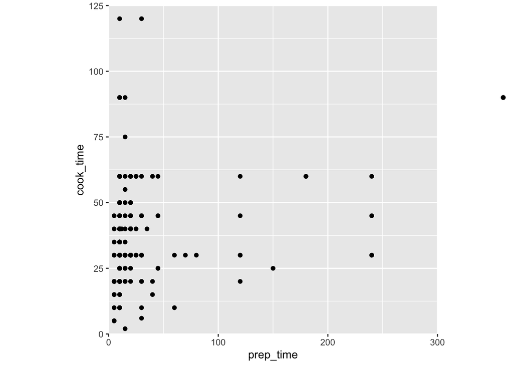